# R Notebook

```r
library('naivebayes')
library('pROC')
library('class')
library('rpart')
library('rio')
library('randomForest')
```

```r
train_indessa <- read.csv("~/R/ML_Artivatic_dataset/train_indessa.csv", stringsAsFactors=FALSE)
summary(train_indessa)
```

```
   member_id          loan_amnt      funded_amnt    funded_amnt_inv     term           batch_enrolled        int_rate
 Min.   :   70473   Min.   :  500   Min.   :  500   Min.   :    0   Length:532428      Length:532428      Min.   : 5.32
 1st Qu.:10866882   1st Qu.: 8000   1st Qu.: 8000   1st Qu.: 8000   Class :character   Class :character   1st Qu.: 9.99
 Median :37095895   Median :13000   Median :13000   Median :13000   Mode  :character   Mode  :character   Median :12.99
 Mean   :35005472   Mean   :14758   Mean   :14744   Mean   :14705                                         Mean   :13.24
 3rd Qu.:58489201   3rd Qu.:20000   3rd Qu.:20000   3rd Qu.:20000                                         3rd Qu.:16.20
 Max.   :73544841   Max.   :35000   Max.   :35000   Max.   :35000                                         Max.   :28.99

    grade            sub_grade          emp_title          emp_length        home_ownership       annual_inc      verification_status
 Length:532428      Length:532428      Length:532428      Length:532428      Length:532428      Min.   :   1200   Length:532428
 Class :character   Class :character   Class :character   Class :character   Class :character   1st Qu.:  45000   Class :character
 Mode  :character   Mode  :character   Mode  :character   Mode  :character   Mode  :character   Median :  65000   Mode  :character
                                                                                                Mean   :  75030
                                                                                                3rd Qu.:  90000
                                                                                                Max.   :9500000
                                                                                                NA's   :3
  pymnt_plan            desc             purpose             title             zip_code          addr_state             dti
 Length:532428      Length:532428      Length:532428      Length:532428      Length:532428      Length:532428      Min.   :  0.00
 Class :character   Class :character   Class :character   Class :character   Class :character   Class :character   1st Qu.: 11.93
 Mode  :character   Mode  :character   Mode  :character   Mode  :character   Mode  :character   Mode  :character   Median : 17.65
                                                                                                                   Mean   : 18.14
                                                                                                                   3rd Qu.: 23.95
                                                                                                                   Max.   :672.52

  delinq_2yrs      inq_last_6mths    mths_since_last_delinq mths_since_last_record    open_acc        pub_rec          revol_bal
 Min.   : 0.0000   Min.   : 0.0000   Min.   :  0.00         Min.   :  0.0          Min.   : 0.00   Min.   : 0.0000   Min.   :      0
 1st Qu.: 0.0000   1st Qu.: 0.0000   1st Qu.: 15.00         1st Qu.: 51.0          1st Qu.: 8.00   1st Qu.: 0.0000   1st Qu.:   6444
 Median : 0.0000   Median : 0.0000   Median : 31.00         Median : 70.0          Median :11.00   Median : 0.0000   Median :  11876
 Mean   : 0.3144   Mean   : 0.6946   Mean   : 34.06         Mean   : 70.1          Mean   :11.55   Mean   : 0.1949   Mean   :  16921
 3rd Qu.: 0.0000   3rd Qu.: 1.0000   3rd Qu.: 50.00         3rd Qu.: 92.0          3rd Qu.:14.00   3rd Qu.: 0.0000   3rd Qu.:  20843
 Max.   :30.0000   Max.   :31.0000   Max.   :180.00         Max.   :121.0          Max.   :90.00   Max.   :86.0000   Max.   :2568995
 NA's   :16        NA's   :16        NA's   :272554         NA's   :450305         NA's   :16      NA's   :16
   revol_util       total_acc      initial_list_status total_rec_int     total_rec_late_fee   recoveries       collection_recovery_fee
 Min.   :  0.00   Min.   :  1.00   Length:532428       Min.   :    0.0   Min.   :  0.000    Min.   :    0.00   Min.   :   0.000
 1st Qu.: 37.70   1st Qu.: 17.00   Class :character    1st Qu.:  441.6   1st Qu.:  0.000    1st Qu.:    0.00   1st Qu.:   0.000
 Median : 56.00   Median : 24.00   Mode  :character    Median : 1072.7   Median :  0.000    Median :    0.00   Median :   0.000
 Mean   : 55.06   Mean   : 25.27                       Mean   : 1753.4   Mean   :  0.395    Mean   :   45.72   Mean   :   4.859
 3rd Qu.: 73.60   3rd Qu.: 32.00                       3rd Qu.: 2234.7   3rd Qu.:  0.000    3rd Qu.:    0.00   3rd Qu.:   0.000
 Max.   :892.30   Max.   :162.00                       Max.   :24205.6   Max.   :358.680    Max.   :33520.27   Max.   :7002.190
 NA's   :287      NA's   :16
 collections_12_mths_ex_med mths_since_last_major_derog application_type   verification_status_joint last_week_pay
 Min.   : 0.0000            Min.   :  0.0               Length:532428      Length:532428             Length:532428
 1st Qu.: 0.0000            1st Qu.: 27.0               Class :character   Class :character          Class :character
 Median : 0.0000            Median : 44.0               Mode  :character   Mode  :character          Mode  :character
 Mean   : 0.0143            Mean   : 44.1
 3rd Qu.: 0.0000            3rd Qu.: 61.0
 Max.   :16.0000            Max.   :180.0
 NA's   :95                 NA's   :399448
 acc_now_delinq       tot_coll_amt       tot_cur_bal      total_rev_hi_lim   loan_status
 Min.   : 0.000000   Min.   :     0.0   Min.   :      0   Min.   :      0   Min.   :0.0000
 1st Qu.: 0.000000   1st Qu.:     0.0   1st Qu.:  29840   1st Qu.:  14000   1st Qu.:0.0000
 Median : 0.000000   Median :     0.0   Median :  80670   Median :  23700   Median :0.0000
 Mean   : 0.005015   Mean   :   213.6   Mean   : 139554   Mean   :  32081   Mean   :0.2363
 3rd Qu.: 0.000000   3rd Qu.:     0.0   3rd Qu.: 208479   3rd Qu.:  39800   3rd Qu.:0.0000
 Max.   :14.000000   Max.   :496651.0   Max.   :8000078   Max.   :9999999   Max.   :1.0000
 NA's   :16          NA's   :42004      NA's   :42004     NA's   :42004
```

```r
term_total = train_indessa$term
term_num = c()
for (t in term_total) {
  term_num = c(term_num, as.integer(substr(t,1,2)))
}
```

```r
home_own = c()
for (h in train_indessa$home_ownership) {
  if (h == "ANY") {
    o = 1
  } else if (h == "MORTGAGE") {
    o = 2
  } else if (h == "NONE") {
    o = 3
  } else if (h == "OTHER") {
    o = 4
  } else if (h == "OWN") {
    o = 5
  } else {
    o = 6
  }
  home_own = c(home_own, o)
}
```

```r
ver_status = c()
for (v in train_indessa$verification_status) {
  if (v == "Not Verified") {
    s = 1
  } else if (h == "Source Verified") {
    s = 2
  } else {
    s = 3
  }
  ver_status = c(ver_status, s)
}
```

```r
train_indessa$delinq_2yrs[is.na(train_indessa$delinq_2yrs)] <- 0
```

```r
train_indessa$inq_last_6mths[is.na(train_indessa$inq_last_6mths)] <- 0
```

```r
train_indessa$mths_since_last_delinq[is.na(train_indessa$mths_since_last_delinq)] <- 0
```

```r
train_indessa$mths_since_last_record[is.na(train_indessa$mths_since_last_record)] <- 0
```

```r
train_indessa$open_acc[is.na(train_indessa$open_acc)] <- 0
```

```r
train_indessa$pub_rec[is.na(train_indessa$pub_rec)] <- 0
```

```r
train_indessa$revol_util[is.na(train_indessa$revol_util)] <- 0
```

```r
train_indessa$total_acc[is.na(train_indessa$total_acc)] <- 0
```

```r
train_indessa$collections_12_mths_ex_med[is.na(train_indessa$collections_12_mths_ex_med)] <- 0
```

```r
train_indessa$mths_since_last_major_derog[is.na(train_indessa$mths_since_last_major_derog)] <- 0
```

```r
app_type = c()
for (a in train_indessa$application_type) {
  if (a == "INDIVIDUAL") {
    t = 1
  } else {
    t = 2
  }
  app_type = c(app_type, t)
}
```

```r
l_week_pay = train_indessa$last_week_pay
l_w_p = c()
for (l in l_week_pay) {
  n = nchar(l)
  l_w_p = c(l_w_p, as.integer(substr(l,1,n - 7)))
}
l_w_p[is.na(l_w_p)] <- 0
```

```r
gra = train_indessa$grade
gd = c()
for (g in gra) {
  if (g == "A") {
    d = 1
  } else if (g == "B") {
    d = 2
  } else if (g == "C") {
    d = 3
  } else if (g == "D") {
    d = 4
  } else {
    d = 5
  }
  gd = c(gd, d)
}
```

```r
train_indessa$acc_now_delinq[is.na(train_indessa$acc_now_delinq)] <- 0
```

```r
train_indessa$tot_coll_amt[is.na(train_indessa$tot_coll_amt)] <- 0
```

```r
train_indessa$tot_cur_bal[is.na(train_indessa$tot_cur_bal)] <- 0
```

```r
summary(train_indessa$tot_cur_bal)
```

```
   Min. 1st Qu.  Median    Mean 3rd Qu.    Max.
      0   23208   65473  128544  196043 8000078
```

```r
train_indessa$total_rev_hi_lim[is.na(train_indessa$total_rev_hi_lim)] <- 0
```

```r
train_indessa$annual_inc[is.na(train_indessa$annual_inc)] <- 40000
```

```r
vanilla_train <-data.frame(train_indessa$member_id, train_indessa$loan_amnt, train_indessa$funded_amnt, train_indessa$funded_amnt_inv, term_num, train_indessa$int_rate, gd, home_own, train_indessa$annual_inc, ver_status, train_indessa$dti, train_indessa$delinq_2yrs, train_indessa$inq_last_6mths, train_indessa$mths_since_last_delinq, train_indessa$mths_since_last_record, train_indessa$open_acc, train_indessa$pub_rec, train_indessa$revol_bal, train_indessa$revol_util, train_indessa$total_acc, train_indessa$total_rec_int, train_indessa$total_rec_late_fee, train_indessa$recoveries, train_indessa$collection_recovery_fee, train_indessa$collections_12_mths_ex_med, train_indessa$mths_since_last_major_derog, app_type, l_w_p, train_indessa$acc_now_delinq, train_indessa$tot_coll_amt, train_indessa$tot_cur_bal, train_indessa$total_rev_hi_lim, train_indessa$loan_status)
```

```r
for (i in 2:32) {
  print(colnames(vanilla_train)[i])
  print(colnames(vanilla_train)[33])
  print(cor(vanilla_train[,i], vanilla_train[,33]))
  print(abs(cor(vanilla_train[,i], vanilla_train[,33])))
}
```

```
[1] "train_indessa.loan_amnt"
[1] "train_indessa.loan_status"
[1] -0.09571273
[1] 0.09571273
[1] "train_indessa.funded_amnt"
[1] "train_indessa.loan_status"
[1] -0.09756343
[1] 0.09756343
[1] "train_indessa.funded_amnt_inv"
[1] "train_indessa.loan_status"
[1] -0.1018775
[1] 0.1018775
[1] "term_num"
[1] "train_indessa.loan_status"
[1] -0.1309594
```

[output cut: 109 more lines]

Select features with absolute correlation with loan_status > 0.1.

```r
vanilla_train.feature_selection <-data.frame(train_indessa$member_id, train_indessa$funded_amnt_inv, term_num, train_indessa$dti, l_w_p, train_indessa$total_rev_hi_lim, train_indessa$loan_status)
```

```r
test_indessa <- read.csv("~/R/ML_Artivatic_dataset/test_indessa.csv", stringsAsFactors=FALSE)
summary(test_indessa)
```

```
   member_id          loan_amnt      funded_amnt    funded_amnt_inv     term           batch_enrolled        int_rate
 Min.   :   70626   Min.   :  500   Min.   :  500   Min.   :    0   Length:354951      Length:354951      Min.   : 5.32
 1st Qu.:10889411   1st Qu.: 8000   1st Qu.: 8000   1st Qu.: 8000   Class :character   Class :character   1st Qu.: 9.99
 Median :37086503   Median :13000   Median :13000   Median :13000   Mode  :character   Mode  :character   Median :12.99
 Mean   :34996354   Mean   :14752   Mean   :14738   Mean   :14699                                         Mean   :13.25
 3rd Qu.:58448923   3rd Qu.:20000   3rd Qu.:20000   3rd Qu.:20000                                         3rd Qu.:16.20
 Max.   :73544827   Max.   :35000   Max.   :35000   Max.   :35000                                         Max.   :28.99

    grade            sub_grade          emp_title          emp_length        home_ownership       annual_inc      verification_status
 Length:354951      Length:354951      Length:354951      Length:354951      Length:354951      Min.   :      0   Length:354951
 Class :character   Class :character   Class :character   Class :character   Class :character   1st Qu.:  45000   Class :character
 Mode  :character   Mode  :character   Mode  :character   Mode  :character   Mode  :character   Median :  65000   Mode  :character
                                                                                                Mean   :  75024
                                                                                                3rd Qu.:  90000
                                                                                                Max.   :9000000
                                                                                                NA's   :1
  pymnt_plan            desc             purpose             title             zip_code          addr_state             dti
 Length:354951      Length:354951      Length:354951      Length:354951      Length:354951      Length:354951      Min.   :   0.00
 Class :character   Class :character   Class :character   Class :character   Class :character   Class :character   1st Qu.:  11.89
 Mode  :character   Mode  :character   Mode  :character   Mode  :character   Mode  :character   Mode  :character   Median :  17.65
                                                                                                                   Mean   :  18.18
                                                                                                                   3rd Qu.:  23.94
                                                                                                                   Max.   :9999.00

  delinq_2yrs      inq_last_6mths    mths_since_last_delinq mths_since_last_record    open_acc        pub_rec         revol_bal
 Min.   : 0.0000   Min.   : 0.0000   Min.   :  0.00         Min.   :  0.00         Min.   : 0.00   Min.   : 0.000   Min.   :      0
 1st Qu.: 0.0000   1st Qu.: 0.0000   1st Qu.: 15.00         1st Qu.: 51.00         1st Qu.: 8.00   1st Qu.: 0.000   1st Qu.:   6441
 Median : 0.0000   Median : 0.0000   Median : 31.00         Median : 70.00         Median :11.00   Median : 0.000   Median :  11873
 Mean   : 0.3144   Mean   : 0.6946   Mean   : 34.08         Mean   : 70.16         Mean   :11.55   Mean   : 0.196   Mean   :  16920
 3rd Qu.: 0.0000   3rd Qu.: 1.0000   3rd Qu.: 50.00         3rd Qu.: 92.00         3rd Qu.:14.00   3rd Qu.: 0.000   3rd Qu.:  20811
 Max.   :39.0000   Max.   :33.0000   Max.   :188.00         Max.   :129.00         Max.   :76.00   Max.   :54.000   Max.   :2904836
 NA's   :13        NA's   :13        NA's   :181758         NA's   :300021         NA's   :13      NA's   :13
   revol_util       total_acc      initial_list_status total_rec_int     total_rec_late_fee   recoveries       collection_recovery_fee
 Min.   :  0.00   Min.   :  1.00   Length:354951       Min.   :    0.0   Min.   :  0.0000   Min.   :    0.00   Min.   :   0.000
 1st Qu.: 37.70   1st Qu.: 17.00   Class :character    1st Qu.:  441.3   1st Qu.:  0.0000   1st Qu.:    0.00   1st Qu.:   0.000
 Median : 56.00   Median : 24.00   Mode  :character    Median : 1074.1   Median :  0.0000   Median :    0.00   Median :   0.000
 Mean   : 55.08   Mean   : 25.27                       Mean   : 1756.9   Mean   :  0.3993   Mean   :   46.22   Mean   :   4.913
 3rd Qu.: 73.60   3rd Qu.: 32.00                       3rd Qu.: 2243.1   3rd Qu.:  0.0000   3rd Qu.:    0.00   3rd Qu.:   0.000
 Max.   :182.80   Max.   :169.00                       Max.   :23062.5   Max.   :286.7476   Max.   :29282.07   Max.   :5569.920
 NA's   :215      NA's   :13
 collections_12_mths_ex_med mths_since_last_major_derog application_type   verification_status_joint last_week_pay
 Min.   : 0.0000            Min.   :  0.00              Length:354951      Length:354951             Length:354951
 1st Qu.: 0.0000            1st Qu.: 27.00              Class :character   Class :character          Class :character
 Median : 0.0000            Median : 44.00              Mode  :character   Mode  :character          Mode  :character
 Mean   : 0.0145            Mean   : 44.08
 3rd Qu.: 0.0000            3rd Qu.: 61.00
 Max.   :20.0000            Max.   :188.00
 NA's   :50                 NA's   :266228
 acc_now_delinq      tot_coll_amt      tot_cur_bal      total_rev_hi_lim
 Min.   :0.000000   Min.   :      0   Min.   :      0   Min.   :      0
 1st Qu.:0.000000   1st Qu.:      0   1st Qu.:  29874   1st Qu.:  13900
 Median :0.000000   Median :      0   Median :  80369   Median :  23700
 Mean   :0.004956   Mean   :    244   Mean   : 139314   Mean   :  32051
 3rd Qu.:0.000000   3rd Qu.:      0   3rd Qu.: 207800   3rd Qu.:  39700
 Max.   :5.000000   Max.   :9152545   Max.   :4447397   Max.   :9999999
 NA's   :13         NA's   :28272     NA's   :28272     NA's   :28272
```

```r
term_total_test = test_indessa$term
term_num_test = c()
for (t_test in term_total_test) {
  term_num_test = c(term_num_test, as.integer(substr(t_test,1,2)))
}
```

```r
l_week_pay_test = test_indessa$last_week_pay
l_w_p_test = c()
for (l_test in l_week_pay_test) {
  n = nchar(l_test)
  l_w_p_test = c(l_w_p_test, as.integer(substr(l_test,1,n - 7)))
}
l_w_p_test[is.na(l_w_p_test)] <- 0
```

```r
test_indessa$total_rev_hi_lim[is.na(test_indessa$total_rev_hi_lim)] <- 0
```

Form a similar test_set.

```r
vanilla_test.feature_selection <-data.frame(test_indessa$member_id, test_indessa$funded_amnt_inv, term_num_test, test_indessa$dti, l_w_p_test, test_indessa$total_rev_hi_lim)
```

```r
smp_size <- floor(0.675 * nrow(vanilla_train.feature_selection))
```

set the seed to make your partition reproducible

```r
set.seed(123)
train_ind <- sample(seq_len(nrow(vanilla_train.feature_selection)), size = smp_size)
```

```r
train <- vanilla_train.feature_selection[train_ind, ]
validation <- vanilla_train.feature_selection[-train_ind, ]
```

```r
normalize <- function(x)
{
    return((x- min(x)) /(max(x)-min(x)))
}
```

```r
train.normalized = data.frame(train$train_indessa.member_id)
validation.normalized = data.frame(validation$train_indessa.member_id)
```

```r
for (i in 2:6) {
  train.normalized[,i] <- normalize(train[,i])
  validation.normalized[,i] <- normalize(validation[,i])
}
```

```r
train.normalized[,7] = data.frame(train$train_indessa.loan_status)
validation.normalized[,7] = data.frame(validation$train_indessa.loan_status)
```

```r
colnames(train.normalized) = colnames(train)
colnames(validation.normalized) = colnames(train)
```

GNB on original data

```r
M = matrix(as.numeric(unlist(train[,2:6])), ncol=5, byrow=F)
y <- factor(train$train_indessa.loan_status)
```

```r
colnames(M) <- c("funded_amnt_inv", "term_num", "dti", "l_w_p", "total_rev_hi_lim")
print(colnames(M))
```

```
[1] "funded_amnt_inv"  "term_num"         "dti"              "l_w_p"            "total_rev_hi_lim"
```

Train the Gaussian Naive Bayes

```r
gnb <- gaussian_naive_bayes(x = M, y = y)
```

```r
summary(gnb)
```

```
========================================================= Gaussian Naive Bayes ==========================================================

- Call: gaussian_naive_bayes(x = M, y = y)
- Samples: 359388
- Features: 5
- Prior probabilities:
    - 0: 0.764
    - 1: 0.236

-----------------------------------------------------------------------------------------------------------------------------------------
```

```r
N = matrix(as.numeric(unlist(validation[,2:6])), ncol=5, byrow=F)
```

```r
colnames(N) <- c("funded_amnt_inv", "term_num", "dti", "l_w_p", "total_rev_hi_lim")
print(colnames(N))
```

```
[1] "funded_amnt_inv"  "term_num"         "dti"              "l_w_p"            "total_rev_hi_lim"
```

Classification

```r
gnb.original.val_output = predict(gnb, newdata = N, type = "prob") # head(gnb %class% M)
```

```
Call:
roc.default(response = factor(validation$train_indessa.loan_status),     predictor = gnb.original.val_output[, 1], percent = TRUE,     plot = TRUE, legacy.axes = TRUE, xlab = "False Positive Percentage",     ylab = "True Positive Percentage", col = "#377eb8", lwd = 4,     print.auc = TRUE)

Data: gnb.original.val_output[, 1] in 132036 controls (factor(validation$train_indessa.loan_status) 0) > 41004 cases (factor(validation$train_indessa.loan_status) 1).
Area under the curve: 68.5%
```

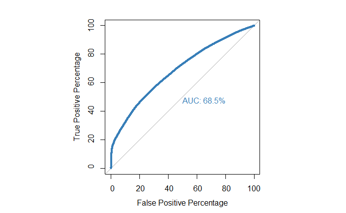

```r
par(pty = 's')
roc(factor(validation$train_indessa.loan_status), gnb.original.val_output[,1], plot = TRUE, legacy.axes = TRUE, percent = TRUE, xlab  = "False Positive Percentage", ylab = "True Positive Percentage", col = "#377eb8", lwd = 4, print.auc = TRUE)
```

GNB on normalized data

```r
M = matrix(as.numeric(unlist(train.normalized[,2:6])), ncol=5, byrow=F)
y <- factor(train$train_indessa.loan_status)
```

```r
colnames(M) <- c("funded_amnt_inv", "term_num", "dti", "l_w_p", "total_rev_hi_lim")
print(colnames(M))
```

```
[1] "funded_amnt_inv"  "term_num"         "dti"              "l_w_p"            "total_rev_hi_lim"
```

Train the Gaussian Naive Bayes

```r
gnb <- gaussian_naive_bayes(x = M, y = y)
```

```r
summary(gnb)
```

```
========================================================= Gaussian Naive Bayes ==========================================================

- Call: gaussian_naive_bayes(x = M, y = y)
- Samples: 359388
- Features: 5
- Prior probabilities:
    - 0: 0.764
    - 1: 0.236

-----------------------------------------------------------------------------------------------------------------------------------------
```

```r
N = matrix(as.numeric(unlist(validation.normalized[,2:6])), ncol=5, byrow=F)
```

```r
colnames(N) <- c("funded_amnt_inv", "term_num", "dti", "l_w_p", "total_rev_hi_lim")
print(colnames(N))
```

```
[1] "funded_amnt_inv"  "term_num"         "dti"              "l_w_p"            "total_rev_hi_lim"
```

Classification

```r
gnb.normalized.val_output = predict(gnb, newdata = N, type = "prob") # head(gnb %class% M)
```

```
Call:
roc.default(response = factor(validation$train_indessa.loan_status),     predictor = gnb.normalized.val_output[, 1], percent = TRUE,     plot = TRUE, legacy.axes = TRUE, xlab = "False Positive Percentage",     ylab = "True Positive Percentage", col = "#377eb8", lwd = 4,     print.auc = TRUE)

Data: gnb.normalized.val_output[, 1] in 132036 controls (factor(validation$train_indessa.loan_status) 0) > 41004 cases (factor(validation$train_indessa.loan_status) 1).
Area under the curve: 61.06%
```

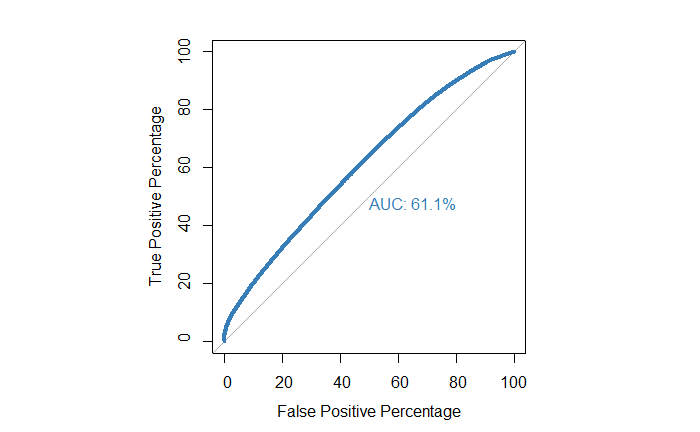

```r
par(pty = 's')
roc(factor(validation$train_indessa.loan_status), gnb.normalized.val_output[,1], plot = TRUE, legacy.axes = TRUE, percent = TRUE, xlab  = "False Positive Percentage", ylab = "True Positive Percentage", col = "#377eb8", lwd = 4, print.auc = TRUE)
```

Train the Logistic Regression

```r
glm.fit <- glm(formula = train_indessa.loan_status ~ train_indessa.funded_amnt_inv + term_num + train_indessa.dti + l_w_p + train_indessa.total_rev_hi_lim, data = train) # , family = binomial, model = TRUE)
```

```r
summary(glm.fit)
```

```
Call:
glm(formula = train_indessa.loan_status ~ train_indessa.funded_amnt_inv +
    term_num + train_indessa.dti + l_w_p + train_indessa.total_rev_hi_lim,
    data = train)

Deviance Residuals:
    Min       1Q   Median       3Q      Max
-0.7890  -0.2566  -0.1604   0.0147   2.8246

Coefficients:
                                 Estimate Std. Error t value Pr(>|t|)
(Intercept)                     3.902e-01  3.184e-03  122.53   <2e-16 ***
train_indessa.funded_amnt_inv  -1.086e-06  9.385e-08  -11.57   <2e-16 ***
term_num                       -3.785e-03  6.765e-05  -55.95   <2e-16 ***
train_indessa.dti              -4.587e-03  8.129e-05  -56.42   <2e-16 ***
l_w_p                           2.330e-03  1.528e-05  152.46   <2e-16 ***
train_indessa.total_rev_hi_lim -8.183e-07  2.285e-08  -35.81   <2e-16 ***
---
Signif. codes:  0 ‘***’ 0.001 ‘**’ 0.01 ‘*’ 0.05 ‘.’ 0.1 ‘ ’ 1

(Dispersion parameter for gaussian family taken to be 0.1622419)

    Null deviance: 64803  on 359387  degrees of freedom
Residual deviance: 58307  on 359382  degrees of freedom
AIC: 366300

Number of Fisher Scoring iterations: 2
```

Classification

```r
glm.original.val_output = predict.glm(glm.fit, newdata = validation, type = "terms") # head(gnb %class% M)
```

```
Call:
roc.default(response = factor(validation$train_indessa.loan_status),     predictor = glm.original.val_output[, 1], percent = TRUE,     plot = TRUE, legacy.axes = TRUE, xlab = "False Positive Percentage",     ylab = "True Positive Percentage", col = "#377eb8", lwd = 4,     print.auc = TRUE)

Data: glm.original.val_output[, 1] in 132036 controls (factor(validation$train_indessa.loan_status) 0) < 41004 cases (factor(validation$train_indessa.loan_status) 1).
Area under the curve: 57.36%
```

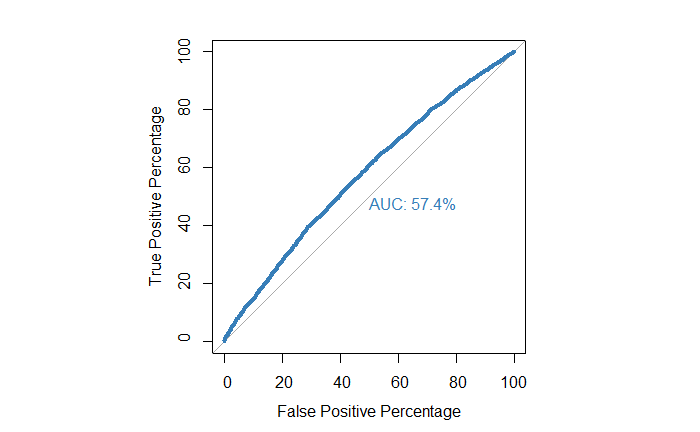

```r
par(pty = 's')
roc(factor(validation$train_indessa.loan_status), glm.original.val_output[,1], plot = TRUE, legacy.axes = TRUE, percent = TRUE, xlab  = "False Positive Percentage", ylab = "True Positive Percentage", col = "#377eb8", lwd = 4, print.auc = TRUE)
```

Train the Logistic Regression

```r
glm.fit <- glm(formula = train_indessa.loan_status ~ train_indessa.funded_amnt_inv + term_num + train_indessa.dti + l_w_p + train_indessa.total_rev_hi_lim, data = train.normalized) # , family = binomial, model = TRUE)
```

```r
summary(glm.fit)
```

```
Call:
glm(formula = train_indessa.loan_status ~ train_indessa.funded_amnt_inv +
    term_num + train_indessa.dti + l_w_p + train_indessa.total_rev_hi_lim,
    data = train.normalized)

Deviance Residuals:
    Min       1Q   Median       3Q      Max
-0.7890  -0.2566  -0.1604   0.0147   2.8246

Coefficients:
                                Estimate Std. Error t value Pr(>|t|)
(Intercept)                     0.253947   0.002234  113.65   <2e-16 ***
train_indessa.funded_amnt_inv  -0.037997   0.003285  -11.57   <2e-16 ***
term_num                       -0.090835   0.001624  -55.95   <2e-16 ***
train_indessa.dti              -3.084640   0.054668  -56.42   <2e-16 ***
l_w_p                           0.708297   0.004646  152.46   <2e-16 ***
train_indessa.total_rev_hi_lim -1.635596   0.045674  -35.81   <2e-16 ***
---
Signif. codes:  0 ‘***’ 0.001 ‘**’ 0.01 ‘*’ 0.05 ‘.’ 0.1 ‘ ’ 1

(Dispersion parameter for gaussian family taken to be 0.1622419)

    Null deviance: 64803  on 359387  degrees of freedom
Residual deviance: 58307  on 359382  degrees of freedom
AIC: 366300

Number of Fisher Scoring iterations: 2
```

Classification

```r
glm.normalized.val_output = predict.glm(glm.fit, newdata = validation.normalized, type = "terms") # head(gnb %class% M)
```

```
Call:
roc.default(response = factor(validation.normalized$train_indessa.loan_status),     predictor = glm.normalized.val_output[, 1], percent = TRUE,     plot = TRUE, legacy.axes = TRUE, xlab = "False Positive Percentage",     ylab = "True Positive Percentage", col = "#377eb8", lwd = 4,     print.auc = TR…

Data: glm.normalized.val_output[, 1] in 132036 controls (factor(validation.normalized$train_indessa.loan_status) 0) < 41004 cases (factor(validation.normalized$train_indessa.loan_status) 1).
Area under the curve: 57.36%
```

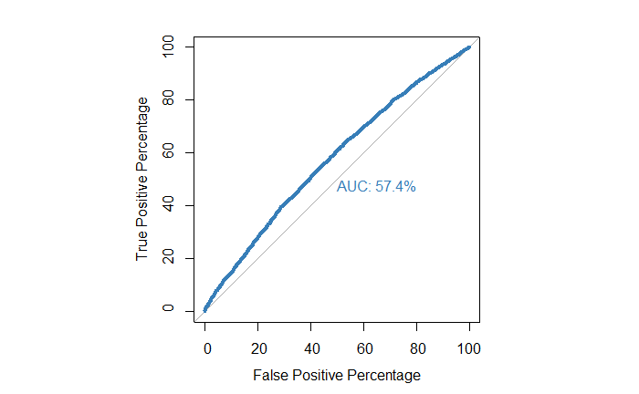

```r
par(pty = 's')
roc(factor(validation.normalized$train_indessa.loan_status), glm.normalized.val_output[,1], plot = TRUE, legacy.axes = TRUE, percent = TRUE, xlab  = "False Positive Percentage", ylab = "True Positive Percentage", col = "#377eb8", lwd = 4, print.auc = TRUE)
```

K - Nearest Neighbors on original data

```r
RES = c()
smp_size_1 <- floor(0.1 * nrow(train))
smp_size_2 <- floor(0.1 * nrow(validation))
for (i in 1:23) {
  # set.seed(123)
  train_ind <- sample(seq_len(nrow(train)), size = smp_size_1)
  val_ind <- sample(seq_len(nrow(validation)), size = smp_size_2)
  knn.original.train <- train[train_ind,]
  knn.original.val <- validation[val_ind,]
  result = knn(train = knn.original.train[,2:6], test = knn.original.val[,2:6], cl = knn.original.train[,7], k=i)
  err = sum(abs(as.numeric(unlist(result)) - knn.original.val[,7]), na.rm = TRUE)
  RES = c(RES,err)
}
```

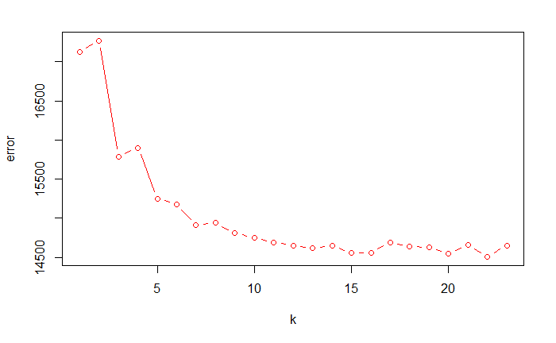

```r
plot(RES, type = 'b', col = 'red', xlab = "k", ylab = "error")
```

```r
knn.original.result = knn(train = train[,2:6], test = validation[,2:6], cl = train[,7], k=5, prob = TRUE)
knn.original.result.prob <- attributes(knn.original.result)$prob
```

```r
knn.original.result.prob.treated = knn.original.result.prob
for (r in 1:173040) {
  t = knn.original.result.prob[r]
  if (knn.original.result[r] == 1) {
    knn.original.result.prob.treated[r] = 1 - t
  } else {
    knn.original.result.prob.treated[r] = t
  }
}
```

```
Call:
roc.default(response = factor(validation$train_indessa.loan_status),     predictor = knn.original.result.prob.treated, percent = TRUE,     plot = TRUE, xlab = "False Positive Percentage", ylab = "True Positive Percentage",     col = "#377eb8", lwd = 4, print.auc = TRUE)

Data: knn.original.result.prob.treated in 132036 controls (factor(validation$train_indessa.loan_status) 0) < 41004 cases (factor(validation$train_indessa.loan_status) 1).
Area under the curve: 36.36%
```

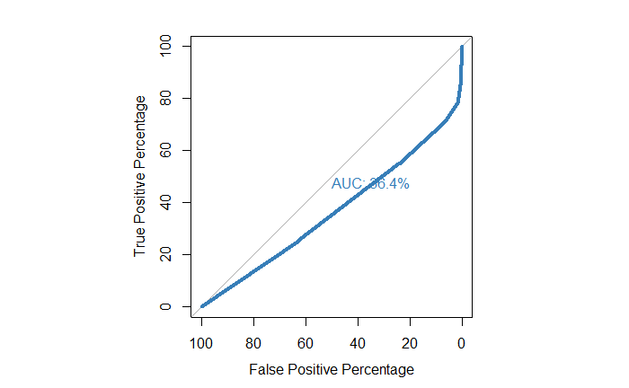

```r
par(pty = 's')
roc(factor(validation$train_indessa.loan_status), knn.original.result.prob.treated, plot = TRUE, percent = TRUE, xlab  = "False Positive Percentage", ylab = "True Positive Percentage", col = "#377eb8", lwd = 4, print.auc = TRUE)
```

K - Nearest Neighbors on normalized data

```r
RES = c()
smp_size_1 <- floor(0.1 * nrow(train))
smp_size_2 <- floor(0.1 * nrow(validation))
for (i in 1:23) {
  # set.seed(123)
  train_ind <- sample(seq_len(nrow(train.normalized)), size = smp_size_1)
  val_ind <- sample(seq_len(nrow(validation.normalized)), size = smp_size_2)
  knn.normalized.train <- train.normalized[train_ind,]
  knn.normalized.val <- validation.normalized[val_ind,]
  result = knn(train = knn.normalized.train[,2:6], test = knn.normalized.val[,2:6], cl = knn.normalized.train[,7], k=i)
  err = sum(abs(as.numeric(unlist(result)) - knn.normalized.val[,7]), na.rm = TRUE)
  RES = c(RES,err)
}
```

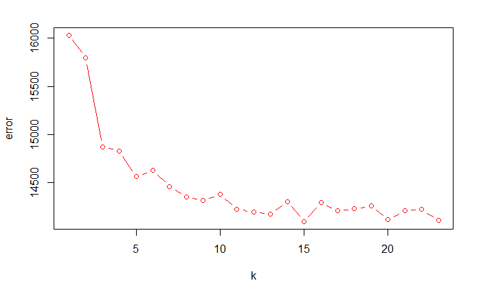

```r
plot(RES, type = 'b', col = 'red', xlab = "k", ylab = "error")
```

```r
knn.normalized.result = knn(train = train.normalized[,2:6], test = validation.normalized[,2:6], cl = train.normalized[,7], k=6, prob = TRUE)
knn.normalized.result.prob <- attributes(knn.normalized.result)$prob
```

```r
knn.normalized.result.prob.treated = knn.normalized.result.prob
for (r in 1:173040) {
  t = knn.normalized.result.prob[r]
  if (knn.normalized.result[r] == 1) {
    knn.normalized.result.prob.treated[r] = 1 - t
  } else {
    knn.normalized.result.prob.treated[r] = t
  }
}
```

```
Call:
roc.default(response = factor(validation.normalized$train_indessa.loan_status),     predictor = knn.normalized.result.prob.treated, percent = TRUE,     plot = TRUE, legacy.axes = TRUE, xlab = "False Positive Percentage",     ylab = "True Positive Percentage", col = "#377eb8", lwd = 4,     print.auc …

Data: knn.normalized.result.prob.treated in 132036 controls (factor(validation.normalized$train_indessa.loan_status) 0) > 41004 cases (factor(validation.normalized$train_indessa.loan_status) 1).
Area under the curve: 62.56%
```

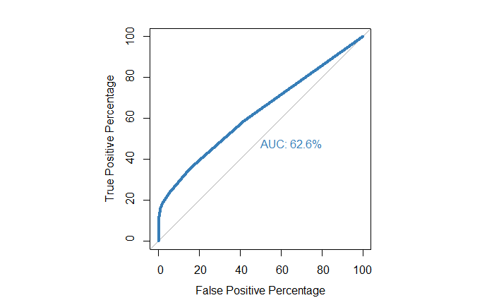

```r
par(pty = 's')
roc(factor(validation.normalized$train_indessa.loan_status), knn.normalized.result.prob.treated, plot = TRUE, legacy.axes = TRUE, percent = TRUE, xlab  = "False Positive Percentage", ylab = "True Positive Percentage", col = "#377eb8", lwd = 4, print.auc = TRUE)
```

Decision Trees on original data

```r
dt.original.fit = rpart(formula = train_indessa.loan_status ~ train_indessa.funded_amnt_inv + term_num + train_indessa.dti + l_w_p + train_indessa.total_rev_hi_lim, data = train, method = "class", control = rpart.control(cp = 0.1))
```

```r
dt.original.result = predict(dt.original.fit, validation[,2:6], type = "prob")
```

```
Call:
roc.default(response = factor(validation$train_indessa.loan_status),     predictor = dt.original.result[, 1], percent = TRUE, plot = TRUE,     legacy.axes = TRUE, xlab = "False Positive Percentage", ylab = "True Positive Percentage",     col = "#377eb8", lwd = 4, print.auc = TRUE)

Data: dt.original.result[, 1] in 132036 controls (factor(validation$train_indessa.loan_status) 0) < 41004 cases (factor(validation$train_indessa.loan_status) 1).
Area under the curve: 37.85%
```

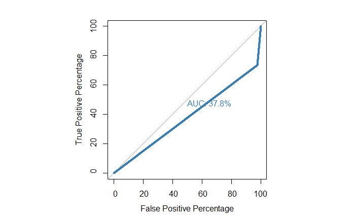

```r
par(pty = 's')
roc(factor(validation$train_indessa.loan_status), dt.original.result[,1], plot = TRUE, legacy.axes = TRUE, percent = TRUE, xlab  = "False Positive Percentage", ylab = "True Positive Percentage", col = "#377eb8", lwd = 4, print.auc = TRUE)
```

Decision Trees on normalized data

```r
dt.normalized.fit = rpart(formula = train_indessa.loan_status ~ train_indessa.funded_amnt_inv + term_num + train_indessa.dti + l_w_p + train_indessa.total_rev_hi_lim, data = train.normalized, method = "class", control = rpart.control(cp = 0.1))
```

```r
dt.normalized.result = predict(dt.normalized.fit, validation.normalized[,2:6], type = "prob")
```

```
Call:
roc.default(response = factor(validation.normalized$train_indessa.loan_status),     predictor = dt.normalized.result[, 1], percent = TRUE, plot = TRUE,     legacy.axes = TRUE, xlab = "False Positive Percentage", ylab = "True Positive Percentage",     col = "#377eb8", lwd = 4, print.auc = TRUE)

Data: dt.normalized.result[, 1] in 132036 controls (factor(validation.normalized$train_indessa.loan_status) 0) < 41004 cases (factor(validation.normalized$train_indessa.loan_status) 1).
Area under the curve: 37.85%
```

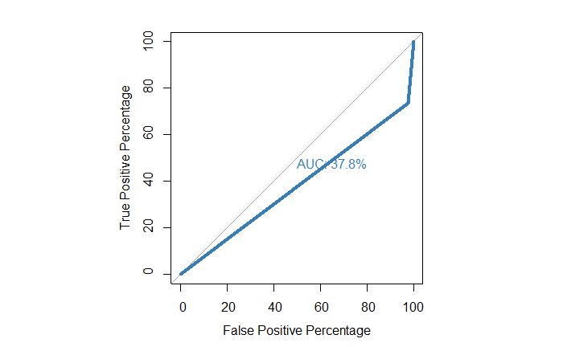

```r
par(pty = 's')
roc(factor(validation.normalized$train_indessa.loan_status), dt.normalized.result[,1], plot = TRUE, legacy.axes = TRUE, percent = TRUE, xlab  = "False Positive Percentage", ylab = "True Positive Percentage", col = "#377eb8", lwd = 4, print.auc = TRUE)
```

Random Forest on original data

```r
smp_size_3 <- floor(0.25 * nrow(train))
smp_size_4 <- floor(0.25 * nrow(validation))
train_ind <- sample(seq_len(nrow(train)), size = smp_size_3)
val_ind <- sample(seq_len(nrow(validation)), size = smp_size_4)
rF.orginal.train <- train[train_ind,]
rF.orginal.val <- validation[val_ind,]
rF.original = randomForest(formula = train_indessa.loan_status ~ train_indessa.funded_amnt_inv + term_num + train_indessa.dti + l_w_p + train_indessa.total_rev_hi_lim, data = rF.orginal.train)
```

```
The response has five or fewer unique values.  Are you sure you want to do regression?
```

```r
rF.original.result = predict(rF.original, newdata = rF.orginal.val)
```

```
Call:
roc.default(response = factor(rF.orginal.val$train_indessa.loan_status),     predictor = rF.original.result, percent = TRUE, plot = TRUE,     legacy.axes = TRUE, xlab = "False Positive Percentage", ylab = "True Positive Percentage",     col = "#377eb8", lwd = 4, print.auc = TRUE)

Data: rF.original.result in 33006 controls (factor(rF.orginal.val$train_indessa.loan_status) 0) < 10254 cases (factor(rF.orginal.val$train_indessa.loan_status) 1).
Area under the curve: 74.6%
```

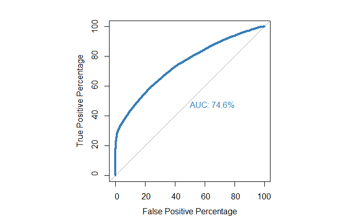

```r
par(pty = 's')
roc(factor(rF.orginal.val$train_indessa.loan_status), rF.original.result, plot = TRUE, legacy.axes = TRUE, percent = TRUE, xlab  = "False Positive Percentage", ylab = "True Positive Percentage", col = "#377eb8", lwd = 4, print.auc = TRUE)
```

Random Forest on normalized data

```r
smp_size_3 <- floor(0.25 * nrow(train))
smp_size_4 <- floor(0.25 * nrow(validation))
train_ind <- sample(seq_len(nrow(train.normalized)), size = smp_size_3)
val_ind <- sample(seq_len(nrow(validation.normalized)), size = smp_size_4)
rF.normalized.train <- train.normalized[train_ind,]
rF.normalized.val <- validation.normalized[val_ind,]
rF.normalized = randomForest(formula = train_indessa.loan_status ~ train_indessa.funded_amnt_inv + term_num + train_indessa.dti + l_w_p + train_indessa.total_rev_hi_lim, data = rF.normalized.train)
```

```
The response has five or fewer unique values.  Are you sure you want to do regression?
```

```r
rF.normalized.result = predict(rF.normalized, newdata = rF.normalized.val)
```

```
Call:
roc.default(response = factor(rF.normalized.val$train_indessa.loan_status),     predictor = rF.normalized.result, percent = TRUE, plot = TRUE,     legacy.axes = TRUE, xlab = "False Positive Percentage", ylab = "True Positive Percentage",     col = "#377eb8", lwd = 4, print.auc = TRUE)

Data: rF.normalized.result in 32825 controls (factor(rF.normalized.val$train_indessa.loan_status) 0) < 10435 cases (factor(rF.normalized.val$train_indessa.loan_status) 1).
Area under the curve: 67.65%
```

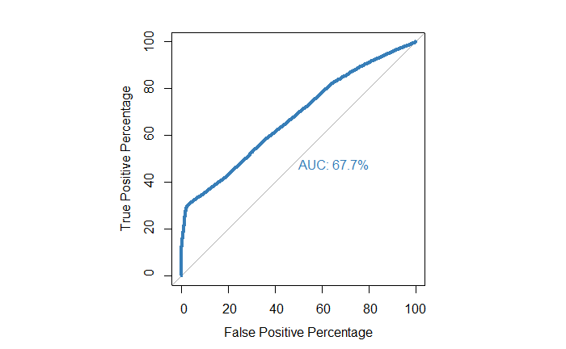

```r
par(pty = 's')
roc(factor(rF.normalized.val$train_indessa.loan_status), rF.normalized.result, plot = TRUE, legacy.axes = TRUE, percent = TRUE, xlab  = "False Positive Percentage", ylab = "True Positive Percentage", col = "#377eb8", lwd = 4, print.auc = TRUE)
```

As we can see above, the best results from 1. Gaussian Naive Bayes 2. Logistic Regression 3. K - Nearest Neighbors 4. Decision Trees 5. Random Forest

on 1. Original 2. Normalized

K - Nearest Neighbors on original data for k = 4

```r
knn.original.result.optimization_1 = knn(train = train[,2:6], test = validation[,2:6], cl = train[,7], k=4, prob = TRUE)
knn.original.result.optimization_1.prob <- attributes(knn.original.result.optimization_1)$prob
```

```r
knn.original.result.optimization_1.prob.treated = knn.original.result.optimization_1.prob
for (r in 1:173040) {
  t = knn.original.result.optimization_1.prob[r]
  if (knn.original.result.optimization_1[r] == 1) {
    knn.original.result.optimization_1.prob.treated[r] = 1 - t
  } else {
    knn.original.result.optimization_1.prob.treated[r] = t
  }
}
```

```
Call:
roc.default(response = factor(validation$train_indessa.loan_status),     predictor = knn.original.result.optimization_1.prob.treated,     percent = TRUE, plot = TRUE, xlab = "False Positive Percentage",     ylab = "True Positive Percentage", col = "#377eb8", lwd = 4,     print.auc = TRUE)

Data: knn.original.result.optimization_1.prob.treated in 132036 controls (factor(validation$train_indessa.loan_status) 0) < 41004 cases (factor(validation$train_indessa.loan_status) 1).
Area under the curve: 36.59%
```

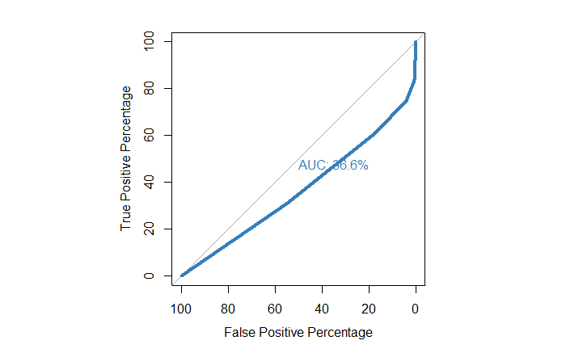

```r
par(pty = 's')
roc(factor(validation$train_indessa.loan_status), knn.original.result.optimization_1.prob.treated, plot = TRUE, percent = TRUE, xlab  = "False Positive Percentage", ylab = "True Positive Percentage", col = "#377eb8", lwd = 4, print.auc = TRUE)
```

K - Nearest Neighbors on original data for k = 6

```r
knn.original.result.optimization_2 = knn(train = train[,2:6], test = validation[,2:6], cl = train[,7], k=6, prob = TRUE)
knn.original.result.optimization_2.prob <- attributes(knn.original.result.optimization_2)$prob
```

```r
knn.original.result.optimization_2.prob.treated = knn.original.result.optimization_2.prob
for (r in 1:173040) {
  t = knn.original.result.optimization_2.prob[r]
  if (knn.original.result.optimization_2[r] == 1) {
    knn.original.result.optimization_2.prob.treated[r] = 1 - t
  } else {
    knn.original.result.optimization_2.prob.treated[r] = t
  }
}
```

```
Call:
roc.default(response = factor(validation$train_indessa.loan_status),     predictor = knn.original.result.optimization_2.prob.treated,     percent = TRUE, plot = TRUE, xlab = "False Positive Percentage",     ylab = "True Positive Percentage", col = "#377eb8", lwd = 4,     print.auc = TRUE)

Data: knn.original.result.optimization_2.prob.treated in 132036 controls (factor(validation$train_indessa.loan_status) 0) > 41004 cases (factor(validation$train_indessa.loan_status) 1).
Area under the curve: 63.92%
```

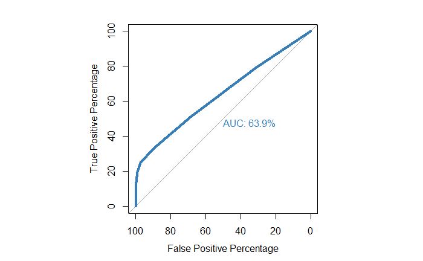

```r
par(pty = 's')
roc(factor(validation$train_indessa.loan_status), knn.original.result.optimization_2.prob.treated, plot = TRUE, percent = TRUE, xlab  = "False Positive Percentage", ylab = "True Positive Percentage", col = "#377eb8", lwd = 4, print.auc = TRUE)
```

K - Nearest Neighbors on normalized data for k = 5

```r
knn.normalized.result.opimization_1 = knn(train = train.normalized[,2:6], test = validation.normalized[,2:6], cl = train.normalized[,7], k=5, prob = TRUE)
knn.normalized.result.opimization_1.prob <- attributes(knn.normalized.result.opimization_1)$prob
```

```r
knn.normalized.result.opimization_1.prob.treated = knn.normalized.result.opimization_1.prob
for (r in 1:173040) {
  t = knn.normalized.result.opimization_1.prob[r]
  if (knn.normalized.result.opimization_1[r] == 1) {
    knn.normalized.result.opimization_1.prob.treated[r] = 1 - t
  } else {
    knn.normalized.result.opimization_1.prob.treated[r] = t
  }
}
```

```
Call:
roc.default(response = factor(validation.normalized$train_indessa.loan_status),     predictor = knn.normalized.result.opimization_1.prob.treated,     percent = TRUE, plot = TRUE, legacy.axes = TRUE, xlab = "False Positive Percentage",     ylab = "True Positive Percentage", col = "#377eb8", lwd = 4, …

Data: knn.normalized.result.opimization_1.prob.treated in 132036 controls (factor(validation.normalized$train_indessa.loan_status) 0) > 41004 cases (factor(validation.normalized$train_indessa.loan_status) 1).
Area under the curve: 62.22%
```

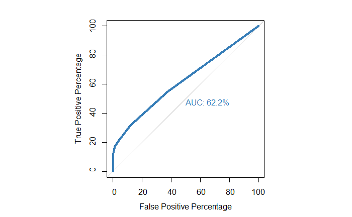

```r
par(pty = 's')
roc(factor(validation.normalized$train_indessa.loan_status), knn.normalized.result.opimization_1.prob.treated, plot = TRUE, legacy.axes = TRUE, percent = TRUE, xlab  = "False Positive Percentage", ylab = "True Positive Percentage", col = "#377eb8", lwd = 4, print.auc = TRUE)
```

K - Nearest Neighbors on normalized data for k = 7

```r
knn.normalized.result.opimization_2 = knn(train = train.normalized[,2:6], test = validation.normalized[,2:6], cl = train.normalized[,7], k=7, prob = TRUE)
knn.normalized.result.opimization_2.prob <- attributes(knn.normalized.result.opimization_2)$prob
```

```r
knn.normalized.result.opimization_2.prob.treated = knn.normalized.result.opimization_2.prob
for (r in 1:173040) {
  t = knn.normalized.result.opimization_2.prob[r]
  if (knn.normalized.result.opimization_2[r] == 1) {
    knn.normalized.result.opimization_2.prob.treated[r] = 1 - t
  } else {
    knn.normalized.result.opimization_2.prob.treated[r] = t
  }
}
```

```
Call:
roc.default(response = factor(validation.normalized$train_indessa.loan_status),     predictor = knn.normalized.result.opimization_2.prob.treated,     percent = TRUE, plot = TRUE, legacy.axes = TRUE, xlab = "False Positive Percentage",     ylab = "True Positive Percentage", col = "#377eb8", lwd = 4, …

Data: knn.normalized.result.opimization_2.prob.treated in 132036 controls (factor(validation.normalized$train_indessa.loan_status) 0) > 41004 cases (factor(validation.normalized$train_indessa.loan_status) 1).
Area under the curve: 62.94%
```

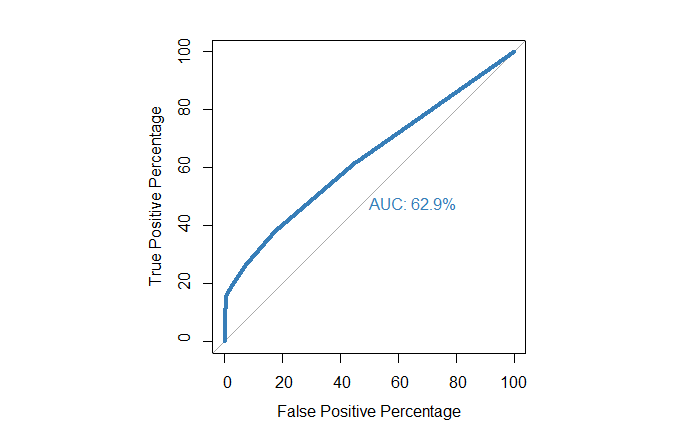

```r
par(pty = 's')
roc(factor(validation.normalized$train_indessa.loan_status), knn.normalized.result.opimization_2.prob.treated, plot = TRUE, legacy.axes = TRUE, percent = TRUE, xlab  = "False Positive Percentage", ylab = "True Positive Percentage", col = "#377eb8", lwd = 4, print.auc = TRUE)
```

Now let’s predict on the vanilla_test.feature_selection with the Random Forest model.

```r
O = matrix(as.numeric(unlist(vanilla_test.feature_selection[,2:6])), ncol=5, byrow=F)
```

```r
colnames(O) <- c("train_indessa.funded_amnt_inv", "term_num", "train_indessa.dti", "l_w_p", "train_indessa.total_rev_hi_lim")
print(colnames(O))
```

```
[1] "train_indessa.funded_amnt_inv"  "term_num"                       "train_indessa.dti"              "l_w_p"
[5] "train_indessa.total_rev_hi_lim"
```

Final Testing

```r
rF.original.test_output = predict(rF.original, newdata = O, type = "class") # head(gnb %class% M)
```

```r
P = data.frame(vanilla_test.feature_selection[,1])
P$loan_status = unlist(rF.original.test_output)
```

```r
colnames(P) <- c("member_id", "loan_status")
print(colnames(P))
```

```
[1] "member_id"   "loan_status"
```

```r
export(P,'submission_2.csv')
```